# Lab_01

Michael Burns

3/26/2020

# Dataset 1:

This dataset includes annual county-level pesticide use estimates for 423 pesticides (active ingredients) applied to agricultural crops grown in the contiguous United States. Two different methods were used to estimate a range of pesticide use for all states except California. Both low and high estimate methods incorporated proprietary surveyed rates for United States Department of Agriculture Crop Reporting Districts, but the estimates differed in how they treated situations when a district was surveyed and pesticide use was not reported. Low estimates assumed zero use in the district for that pesticide; however, high estimates treated the unreported use of pesticides as missing data and estimated the pesticide usage from neighboring locations within the same region.

```r
data_2014 <- read_csv("../teaching_APSC8280/datasets/pesticide-use/2014.csv")
data_2015 <- read_csv("../teaching_APSC8280/datasets/pesticide-use/2015.csv")
data_dictionary <- read_csv("../teaching_APSC8280/datasets/pesticide-use/dictionary.csv")
head(data_2014)
```

```
## # A tibble: 6 x 6
##   COMPOUND  YEAR STATE_CODE COUNTY_CODE LOW_ESTIMATE HIGH_ESTIMATE
##   <chr>    <dbl> <chr>      <chr>              <dbl>         <dbl>
## 1 2,4-D     2014 01         001                1699.         1886.
## 2 2,4-D     2014 01         003                7514.         8472.
## 3 2,4-D     2014 01         005                2614.         2889.
## 4 2,4-D     2014 01         007                1259.         1278.
## 5 2,4-D     2014 01         009                7590.         7756.
## 6 2,4-D     2014 01         011                1319.         1408.
```

```r
head(data_2015)
```

```
## # A tibble: 6 x 6
##   COMPOUND           YEAR STATE_CODE COUNTY_CODE LOW_ESTIMATE HIGH_ESTIMATE
##   <chr>             <dbl> <chr>      <chr>              <dbl>         <dbl>
## 1 1-Methyl Cyclopr…  2015 41         001                   NA           0
## 2 1-Methyl Cyclopr…  2015 41         021                   NA           0.1
## 3 1-Methyl Cyclopr…  2015 41         027                   NA           1.7
## 4 1-Methyl Cyclopr…  2015 41         049                   NA           0.1
## 5 1-Methyl Cyclopr…  2015 41         055                   NA           0
## 6 1-Methyl Cyclopr…  2015 41         059                   NA           5.7
```

```r
head(data_dictionary)
```

```
## # A tibble: 6 x 4
##   STATE_CODE COUNTY_CODE COUNTY         STATE
##   <chr>      <chr>       <chr>          <chr>
## 1 01         001         Autauga County AL
## 2 01         003         Baldwin County AL
## 3 01         005         Barbour County AL
## 4 01         007         Bibb County    AL
## 5 01         009         Blount County  AL
## 6 01         011         Bullock County AL
```

```r
data_both <- bind_rows(data_2014, data_2015)
data_full <- data_both %>%
  full_join(data_dictionary) %>%
  select(c(COMPOUND, YEAR, STATE, COUNTY, LOW_ESTIMATE, HIGH_ESTIMATE))
head(data_full)
```

```
## # A tibble: 6 x 6
##   COMPOUND  YEAR STATE COUNTY         LOW_ESTIMATE HIGH_ESTIMATE
##   <chr>    <dbl> <chr> <chr>                 <dbl>         <dbl>
## 1 2,4-D     2014 AL    Autauga County        1699.         1886.
## 2 2,4-D     2014 AL    Baldwin County        7514.         8472.
## 3 2,4-D     2014 AL    Barbour County        2614.         2889.
## 4 2,4-D     2014 AL    Bibb County           1259.         1278.
## 5 2,4-D     2014 AL    Blount County         7590.         7756.
## 6 2,4-D     2014 AL    Bullock County        1319.         1408.
```

1. What are the median amounts of the top ten pesticides (high estimate usage)?

```r
data_full %>%
  group_by(COMPOUND) %>%
  summarise(median_usage = median(HIGH_ESTIMATE)) %>%
  arrange(desc(median_usage)) %>%
  slice(1:10)
```

```
## # A tibble: 10 x 2
##    COMPOUND                median_usage
##    <chr>                          <dbl>
##  1 Glyphosate                    15234
##  2 Propanil                       3175.
##  3 2,4-D                          2997.
##  4 Atrazine                       2354.
##  5 Metolachlor-S                  2323.
##  6 Petroleum Distillate           2126.
##  7 Dichloropropene                1673.
##  8 Acetochlor                     1382.
##  9 Pendimethalin                  1149.
## 10 Copper Sulfate TrIBAsic         793.
```

2. Which pesticide has the largest total usage over the two year period? In which state was this pesticide used the most? In which state was it used the least?

```r
most_used <- data_full %>%
  group_by(COMPOUND) %>%
  summarise(total_usage = sum(HIGH_ESTIMATE)) %>%
  arrange(desc(total_usage)) %>%
  slice(1) %>%
  pull(COMPOUND)

data_full %>%
  filter(COMPOUND == most_used) %>%
  group_by(STATE) %>%
  summarise(total_used = sum(HIGH_ESTIMATE)) %>%
  arrange(desc(total_used)) %>%
  filter(row_number() == 1 | row_number() == n())
```

```
## # A tibble: 2 x 2
##   STATE total_used
##   <chr>      <dbl>
## 1 IA     22965254.
## 2 RI         1616.
```

3. Which state has the least average percentage difference between the high and low estimates of the reported pesticide usage? Entries with no low etimates should be excluded

```r
data_full %>%
  filter(!is.na(LOW_ESTIMATE)) %>%
  group_by(STATE) %>%
  summarise(Low = sum(LOW_ESTIMATE),
            High = sum(HIGH_ESTIMATE),
            percent_diff = (High - Low) / High) %>%
  arrange(percent_diff) %>%
  slice(1)
```

```
## # A tibble: 1 x 4
##   STATE       Low      High percent_diff
##   <chr>     <dbl>     <dbl>        <dbl>
## 1 CA    59524168. 59524168.            0
```

4. Which state(s) used the most number of pesticides? How many pesticides did that(those) state(s) use?

```r
data_full %>%
  filter(!is.na(COMPOUND)) %>%
  group_by(STATE, COMPOUND) %>%
  summarise(n_uses = n()) %>%
  group_by(STATE) %>%
  summarise(n_compunds = n()) %>%
  arrange(desc(n_compunds))
```

```
## # A tibble: 48 x 2
##    STATE n_compunds
##    <chr>      <int>
##  1 CA           311
##  2 WA           253
##  3 OR           252
##  4 FL           243
##  5 GA           242
##  6 TX           239
##  7 ID           234
##  8 VA           232
##  9 NC           230
## 10 MI           227
## # … with 38 more rows
```

5. Which county used the largest amount of pesticides? What is the state of that county in?

```r
data_full %>%
  group_by(COUNTY, STATE) %>%
  mutate(total_used = sum(HIGH_ESTIMATE)) %>%
  arrange(desc(total_used)) %>%
  select(c(COUNTY, STATE)) %>%
  head(1)
```

```
## # A tibble: 1 x 2
## # Groups:   COUNTY, STATE [1]
##   COUNTY       STATE
##   <chr>        <chr>
## 1 Grant County WA
```

6. Which state(s) had the largest number of counties? What was the number of counties in that(those) states?

```r
data_full %>%
  select(c(STATE, COUNTY)) %>%
  group_by(STATE) %>%
  summarise(n_counties = n()) %>%
  arrange(desc(n_counties))
```

```
## # A tibble: 57 x 2
##    STATE n_counties
##    <chr>      <int>
##  1 TX         56420
##  2 GA         39943
##  3 NC         30826
##  4 KY         30193
##  5 IL         28349
##  6 MI         27420
##  7 MO         27407
##  8 OH         27002
##  9 IN         26708
## 10 VA         24677
## # … with 47 more rows
```

7. List the top ten states with the largest total median usage per number of counties grouped by year

```r
data_full %>%
  group_by(STATE, COUNTY) %>%
  filter(!is.na(HIGH_ESTIMATE)) %>%
  summarise(median = median(HIGH_ESTIMATE)) %>%
  group_by(STATE) %>%
  summarise(n_counties = n(),
            median_per_county = sum(median) / n_counties) %>%
  arrange(desc(median_per_county)) %>%
  slice(1:10)
```

```
## # A tibble: 10 x 3
##    STATE n_counties median_per_county
##    <chr>      <int>             <dbl>
##  1 CA            57             198.
##  2 DE             3             186.
##  3 ND            53             162.
##  4 IA            99              91.0
##  5 NE            93              88.6
##  6 SD            66              85.3
##  7 AR            74              74.7
##  8 KS           105              69.5
##  9 IL           102              69.5
## 10 MN            87              64.5
```

8. List the top five states with the largest amount/no of pesticides grouped by year?

```r
data_full %>%
  group_by(YEAR, STATE, COMPOUND) %>%
  filter(!is.na(HIGH_ESTIMATE) &
           !is.na(COMPOUND)) %>%
  summarise(n = n(),
            est_of_pest = sum(HIGH_ESTIMATE)) %>%
  group_by(YEAR, STATE) %>%
  summarise(n_pesticides = n(),
            total_pesticide = sum(est_of_pest),
            amt_pest_per_num = total_pesticide / n_pesticides) %>%
  arrange(desc(amt_pest_per_num)) %>%
  group_by(YEAR) %>%
  top_n(n = 5, wt = amt_pest_per_num) %>%
  arrange(YEAR, amt_pest_per_num)
```

```
## # A tibble: 10 x 5
## # Groups:   YEAR [2]
##     YEAR STATE n_pesticides total_pesticide amt_pest_per_num
##    <dbl> <chr>        <int>           <dbl>            <dbl>
##  1  2014 NE             170       21040188.          123766.
##  2  2014 KS             170       21181997.          124600.
##  3  2014 IL             180       26555737.          147532.
##  4  2014 IA             157       27853530.          177411.
##  5  2014 CA             311       59524168.          191396.
##  6  2015 NE             160       20378125.          127363.
##  7  2015 FL             209       27206445.          130174.
##  8  2015 KS             169       25248883.          149402.
##  9  2015 IL             181       27179762.          150164.
## 10  2015 IA             157       26496214.          168766.
```

9. List the top five states by largest median usage of chemicals

```r
data_full %>%
  filter(!is.na(HIGH_ESTIMATE)) %>%
  group_by(STATE) %>%
  summarise(median_chem_use = median(HIGH_ESTIMATE)) %>%
  arrange(desc(median_chem_use)) %>%
  slice(1:5) %>%
  pull(STATE)
```

```
## [1] "ND" "CA" "DE" "IA" "NE"
```

10. Which pesticide was used in the most number of states?

```r
data_full %>%
  filter(!is.na(HIGH_ESTIMATE)) %>%
  group_by(STATE, COMPOUND) %>%
  summarise(county_uses = n()) %>%
  group_by(COMPOUND) %>%
  summarise(state_uses = n()) %>%
  arrange(desc(state_uses))
```

```
## # A tibble: 413 x 2
##    COMPOUND       state_uses
##    <chr>               <int>
##  1 2,4-D                  48
##  2 Abamectin              48
##  3 Atrazine               48
##  4 Azoxystrobin           48
##  5 Bentazone              48
##  6 Bifenthrin             48
##  7 Chlorothalonil         48
##  8 Chlorpyrifos           48
##  9 Clethodim              48
## 10 Clothianidin           48
## # … with 403 more rows
```

11. What pesticide has the largest percentage increase in the number of states using it from 2014 to 2015?

```r
data_full %>%
  filter(!is.na(HIGH_ESTIMATE)) %>%
  group_by(YEAR, STATE, COMPOUND) %>%
  summarise(county_uses = n()) %>%
  group_by(YEAR, COMPOUND) %>%
  summarise(state_uses = n()) %>%
  pivot_wider(id_cols = COMPOUND, names_from = YEAR, values_from = state_uses) %>%
  mutate(delta_use = `2015` - `2014`,
         percent_change = (delta_use / `2014`) * 100) %>%
  arrange(desc(percent_change)) %>%
  slice(1)
```

```
## # A tibble: 1 x 5
##   COMPOUND `2014` `2015` delta_use percent_change
##   <chr>     <int>  <int>     <int>          <dbl>
## 1 Diclofop      2     10         8            400
```

12. List the top five states with the largest increase in median usage of pesticides from 2014 to 2015

```r
data_full %>%
  filter(!is.na(HIGH_ESTIMATE)) %>%
  group_by(STATE, YEAR) %>%
  summarise(median_use = median(HIGH_ESTIMATE)) %>%
  pivot_wider(id_cols = STATE, names_from = YEAR, values_from = median_use) %>%
  mutate(delta_use = `2015` - `2014`) %>%
  arrange(desc(delta_use)) %>%
  head(5)
```

```
## # A tibble: 5 x 4
## # Groups:   STATE [5]
##   STATE `2014` `2015` delta_use
##   <chr>  <dbl>  <dbl>     <dbl>
## 1 DE      71.3  116.      44.9
## 2 ND     127.   171.      44.6
## 3 SD      56     89.1     33.1
## 4 MT      25     35.3     10.3
## 5 LA      35.2   44.6      9.40
```

13. Plot one graph that highlight something interesting about the dataset

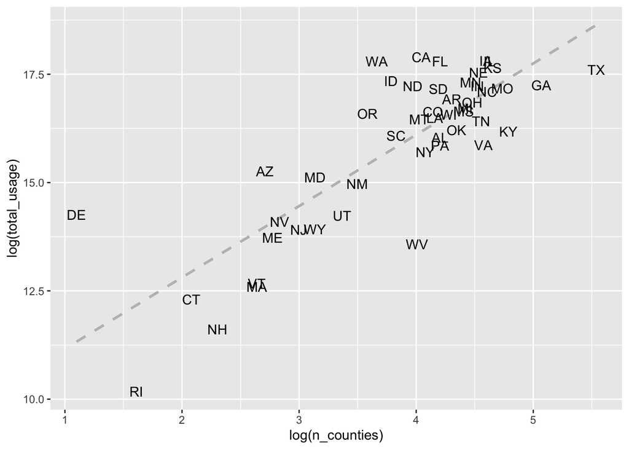

```r
#How does the change in the number of pesticides change with the median usage in states?
data_full %>%
  filter(!is.na(HIGH_ESTIMATE)) %>%
  group_by(STATE, COUNTY) %>%
  summarise(n_chemicals = n(),
            usage = sum(HIGH_ESTIMATE)) %>%
  group_by(STATE) %>%
  summarise(n_chemicals = sum(n_chemicals),
            total_usage = sum(usage),
            n_counties = n()) %>%
  ggplot(aes(x = log(n_counties), y = log(total_usage)))+
  geom_smooth(color = "gray", lty = "dashed", method = "lm", se = F)+
  geom_text(aes(label = STATE))
```

There seems to be a slight linear trend with the log estimated total usage of chemicals and the log number of counties.

# Dataset 2:

These files provide detailed data about the circumstances of personal injury road accidents in Great Britain from 2005 onwards, the types of vehicles involved and the consequential casualties. The statistics relate only to personal injury accidents on public roads that are reported to the police, and subsequently recorded, using the STATS19 accident reporting form. Information on damage-only accidents, with no human casualties or accidents on private roads or car parks are not included in this data.

Very few, if any, fatal accidents do not become known to the police although it is known that a considerable proportion of non-fatal injury accidents are not reported to the police. Figures for deaths refer to persons killed immediately or who died within 30 days of the accident. This is the usual international definition, adopted by the Vienna Convention in 1968.

```r
accidents <- read_csv("../Data/Lab_1_Dataset_2/Accidents0514.csv")
casualties <- read_csv("../Data/Lab_1_Dataset_2/Casualties0514.csv")
vehicles <- read_csv("../Data/Lab_1_Dataset_2/Vehicles0514.csv")
head(accidents)
```

```
## # A tibble: 6 x 32
##   Accident_Index Location_Eastin… Location_Northi… Longitude Latitude
##   <chr>                     <dbl>            <dbl>     <dbl>    <dbl>
## 1 200501BS00001            525680           178240    -0.191     51.5
## 2 200501BS00002            524170           181650    -0.212     51.5
## 3 200501BS00003            524520           182240    -0.206     51.5
## 4 200501BS00004            526900           177530    -0.174     51.5
## 5 200501BS00005            528060           179040    -0.157     51.5
## 6 200501BS00006            524770           181160    -0.203     51.5
## # … with 27 more variables: Police_Force <dbl>, Accident_Severity <dbl>,
## #   Number_of_Vehicles <dbl>, Number_of_Casualties <dbl>, Date <chr>,
## #   Day_of_Week <dbl>, Time <time>, `Local_Authority_(District)` <dbl>,
## #   `Local_Authority_(Highway)` <chr>, `1st_Road_Class` <dbl>,
## #   `1st_Road_Number` <dbl>, Road_Type <dbl>, Speed_limit <dbl>,
## #   Junction_Detail <dbl>, Junction_Control <dbl>, `2nd_Road_Class` <dbl>,
## #   `2nd_Road_Number` <dbl>, `Pedestrian_Crossing-Human_Control` <dbl>,
## #   `Pedestrian_Crossing-Physical_Facilities` <dbl>,
## #   Light_Conditions <dbl>, Weather_Conditions <dbl>,
## #   Road_Surface_Conditions <dbl>, Special_Conditions_at_Site <dbl>,
## #   Carriageway_Hazards <dbl>, Urban_or_Rural_Area <dbl>,
## #   Did_Police_Officer_Attend_Scene_of_Accident <dbl>,
## #   LSOA_of_Accident_Location <chr>
```

```r
head(casualties)
```

```
## # A tibble: 6 x 15
##   Accident_Index Vehicle_Referen… Casualty_Refere… Casualty_Class
##   <chr>                     <dbl>            <dbl>          <dbl>
## 1 200501BS00001                 1                1              3
## 2 200501BS00002                 1                1              2
## 3 200501BS00003                 2                1              1
## 4 200501BS00004                 1                1              3
## 5 200501BS00005                 1                1              1
## 6 200501BS00006                 2                1              1
## # … with 11 more variables: Sex_of_Casualty <dbl>, Age_of_Casualty <dbl>,
## #   Age_Band_of_Casualty <dbl>, Casualty_Severity <dbl>,
## #   Pedestrian_Location <dbl>, Pedestrian_Movement <dbl>,
## #   Car_Passenger <dbl>, Bus_or_Coach_Passenger <dbl>,
## #   Pedestrian_Road_Maintenance_Worker <dbl>, Casualty_Type <dbl>,
## #   Casualty_Home_Area_Type <dbl>
```

```r
head(vehicles)
```

```
## # A tibble: 6 x 22
##   Accident_Index Vehicle_Referen… Vehicle_Type Towing_and_Arti…
##   <chr>                     <dbl>        <dbl>            <dbl>
## 1 200501BS00001                 1            9                0
## 2 200501BS00002                 1           11                0
## 3 200501BS00003                 1           11                0
## 4 200501BS00003                 2            9                0
## 5 200501BS00004                 1            9                0
## 6 200501BS00005                 1            3                0
## # … with 18 more variables: Vehicle_Manoeuvre <dbl>,
## #   `Vehicle_Location-Restricted_Lane` <dbl>, Junction_Location <dbl>,
## #   Skidding_and_Overturning <dbl>, Hit_Object_in_Carriageway <dbl>,
## #   Vehicle_Leaving_Carriageway <dbl>, Hit_Object_off_Carriageway <dbl>,
## #   `1st_Point_of_Impact` <dbl>, `Was_Vehicle_Left_Hand_Drive?` <dbl>,
## #   Journey_Purpose_of_Driver <dbl>, Sex_of_Driver <dbl>,
## #   Age_of_Driver <dbl>, Age_Band_of_Driver <dbl>,
## #   `Engine_Capacity_(CC)` <dbl>, Propulsion_Code <dbl>,
## #   Age_of_Vehicle <dbl>, Driver_IMD_Decile <dbl>,
## #   Driver_Home_Area_Type <dbl>
```

1. What fraction of accidents occur in rural areas?

```r
# Rural code number is 2
accidents %>%
  summarise(prop_rural = mean(Urban_or_Rural_Area == 2))
```

```
## # A tibble: 1 x 1
##   prop_rural
##        <dbl>
## 1      0.357
```

2. Do accidents in high-speed-limit areas have more casualties? Compute the Pearson correlation coefficient between the speed limit and the ratio of the number of casualties to accidents for each speed limit. (Group the data by speed limit)

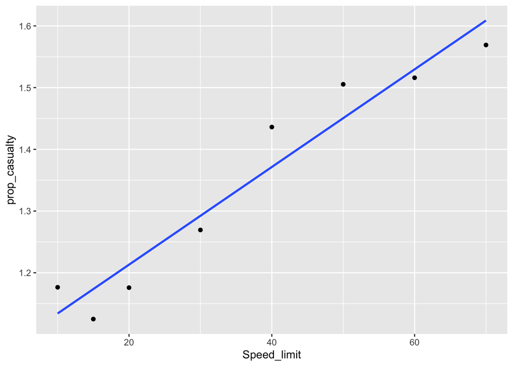

```r
prop_casualty_by_speed <- accidents %>%
  group_by(Speed_limit) %>%
  summarise(prop_casualty = mean(Number_of_Casualties))

prop_casualty_by_speed %>%
  ggplot(aes(x = Speed_limit, y = prop_casualty))+
  geom_point()+
  geom_smooth(method = "lm", se = F)
```

```r
cor.test(x = prop_casualty_by_speed$Speed_limit, y = prop_casualty_by_speed$prop_casualty, method = "pearson")
```

```
##
##  Pearson's product-moment correlation
##
## data:  prop_casualty_by_speed$Speed_limit and prop_casualty_by_speed$prop_casualty
## t = 9.1435, df = 6, p-value = 9.628e-05
## alternative hypothesis: true correlation is not equal to 0
## 95 percent confidence interval:
##  0.8181725 0.9940148
## sample estimates:
##       cor
## 0.9659391
```

3. When is the most dangerous time to drive? Find the hour of the day that has the highest occurance of fatal accidents, normalized by the total number of accidents that occured in that hour (compute the corresponding frequency of fatal accidents to all accidents in that hour). Note: round accident times down. For example, if an accident occured at 23:55 it occured in hour 23

```r
# fatal accidents code = 1
accidents %>%
  select(c(Time, Accident_Severity)) %>%
  mutate(Time = lubridate::hour(Time)) %>%
  group_by(Time) %>%
  summarise(prop_fatal = mean(Accident_Severity)) %>%
  arrange(desc(prop_fatal)) %>%
  slice(1)
```

```
## # A tibble: 1 x 2
##    Time prop_fatal
##   <int>      <dbl>
## 1     8       2.88
```

4. Is there a linear treand in the number of accidents that occured each year? Return the slope in units of increased number of accidents per year

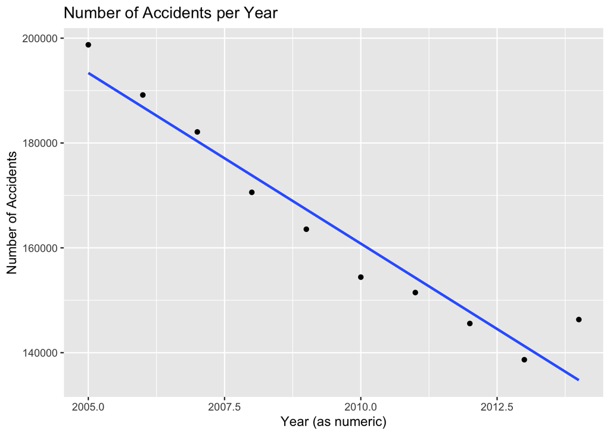

```r
accidents %>%
  select(Date) %>%
  mutate(Date = str_remove(string = Date, pattern = ".*/")) %>%
  group_by(Date) %>%
  summarise(n_accidents = n()) %>%
  ggplot(aes(x = as.numeric(Date), y = n_accidents))+
  geom_point()+
  geom_smooth(method = "lm", se = F)+
  labs(title = "Number of Accidents per Year",
       x = "Year (as numeric)",
       y = "Number of Accidents")
```

```r
accidents %>%
  select(Date) %>%
  mutate(Date = as.double(str_remove(string = Date, pattern = ".*/"))) %>%
  group_by(Date) %>%
  summarise(n_accidents = n()) %>%
  summarise(cov = cov(Date, n_accidents),
            var_date = var(Date),
            slope = cov / var_date)
```

```
## # A tibble: 1 x 3
##       cov var_date  slope
##     <dbl>    <dbl>  <dbl>
## 1 -59691.     9.17 -6512.
```

5. How many times more likely are accidents involving male car drivers to be fatal compared to accidents involving female car drivers? Report your answer as the ratio of fatality rates of males to females. Ignore all accidents where the driver wasn’t driving a car.

```r
# fatal = 1
# men code = 1, female code = 2
# car vehicle type = 9

vehicle_casualty <- casualties %>%
  full_join(vehicles)
vehicle_casualty %>%
  filter(Casualty_Severity == 1 & Vehicle_Type == 9) %>%
  select(Sex_of_Driver) %>%
  filter(Sex_of_Driver != -1 & Sex_of_Driver != 3) %>%
  group_by(Sex_of_Driver) %>%
  summarise(n_individuals = sum(Sex_of_Driver)) %>%
  ungroup() %>%
  pivot_wider(names_from = Sex_of_Driver, values_from = n_individuals) %>%
  mutate(n_men = `1`,
         n_women = `2`) %>%
  select(c(n_men, n_women)) %>%
  mutate(ratio_men_to_women = n_men / n_women)
```

```
## # A tibble: 1 x 3
##   n_men n_women ratio_men_to_women
##   <dbl>   <dbl>              <dbl>
## 1 10848    6582               1.65
```

6. How fast do the number of car accidents drop off with age? Only consider car drivers who are legally allowed to drive in the UK (17 years and older). Find the rate at which the number of accidents exponentially decays with age. Age is measured in years. Assume that the number of accidents is exponentially distributed with age for the drivers over the age of 17?

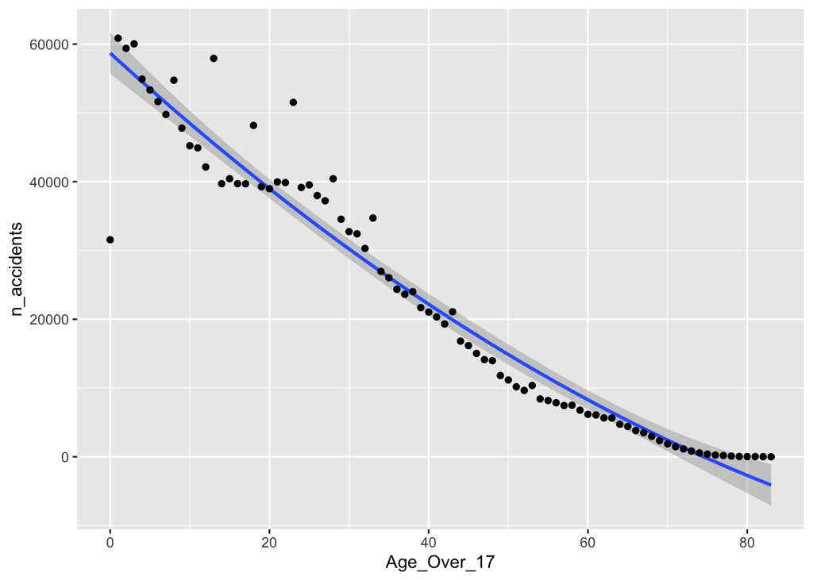

```r
accidents_over_17 <- vehicles %>%
  filter(Vehicle_Type == 9 & Age_of_Driver >= 17) %>%
  select(Age_of_Driver) %>%
  mutate(Age_Over_17 = Age_of_Driver - 17) %>%
  group_by(Age_Over_17) %>%
  summarise(n_accidents = n())

accidents_over_17 %>%
  ggplot(aes(x = Age_Over_17, y = n_accidents))+
  geom_smooth(method = "lm", formula = y~poly(x, 2, raw = TRUE))+
  geom_point()
```

```r
lm(n_accidents ~ poly(Age_Over_17, 2, raw = TRUE), data = accidents_over_17) %>%
  tidy() %>%
  select(c(term, estimate)) %>%
  pivot_wider(names_from = term, values_from = estimate) %>%
  mutate(Intercept = `(Intercept)`,
         X_coef = `poly(Age_Over_17, 2, raw = TRUE)1`,
         `X^2_coef` = `poly(Age_Over_17, 2, raw = TRUE)2`) %>%
  select(c(Intercept, X_coef, `X^2_coef`))
```

```
## # A tibble: 1 x 3
##   Intercept X_coef `X^2_coef`
##       <dbl>  <dbl>      <dbl>
## 1    58697. -1058.       3.63
```

7. How many times more likely are you to be in an accident where you skid, jackknife, or overturn (as opposed to an accident where you don’t) when it’s raining or snowing compared to nice weather with no high winds? Ignore accients where the weather is unknown or missing

```r
# Nice weather with no high winds = 1
# Snowing, no high winds = 3
# Raining, no high winds = 2
# Unknown or missing data = 9 & -1.
# No skidding, overturning, or jackknifing = 0
# Missing data = -1

vehicles_accidents <- vehicles %>%
  full_join(accidents)
vehicles_accidents %>%
  select(c(Weather_Conditions, Skidding_and_Overturning)) %>%
  filter(Weather_Conditions != 9 & Weather_Conditions != -1 & Skidding_and_Overturning != -1) %>%
  filter(Weather_Conditions != 4 &
           Weather_Conditions != 5 &
           Weather_Conditions != 6 &
           Weather_Conditions != 7 &
           Weather_Conditions != 8) %>%
  group_by(Weather_Conditions) %>%
  summarise(accidents_in_bad_weather = mean(Skidding_and_Overturning != 0)) %>%
  pivot_wider(names_from = Weather_Conditions, values_from = accidents_in_bad_weather) %>%
  mutate(Nice_Weather_Accidents = `1`,
         Bad_Weather_Accidents = `2` + `3`) %>%
  select(c(Nice_Weather_Accidents, Bad_Weather_Accidents)) %>%
  summarise(Bad_to_Good_Weather_Ratio = Bad_Weather_Accidents / Nice_Weather_Accidents)
```

```
## # A tibble: 1 x 1
##   Bad_to_Good_Weather_Ratio
##                       <dbl>
## 1                      4.95
```